# GEO 3/446 Exercise #3

Wind Energy Suitability Analysis

Author

C. Scott Smith, PhD AICP (Instructor)

Published

October 11, 2023

## Background

Generating power from cleaner sources of energy is important, but such energy still needs to find its way from the power source to the consumer. In an effort to boost California’s wind power infrastructure, southern California’s largest electric utility, Southern California Edison (SCE), is planning a renewable transmission project with the capacity to transmit 4,500 megawatts of electricity from wind farms under development in the region. You have been hired by SCE to identify three feasible alignment scenarios for a transmission line that will connect to the regional electricity grid. Specifically, the transmission line will connect a substation in Kern County to another substation located in Los Angeles County; it is your job to identify an optimal path between the two locations.

Siting such a transmission line is not a trivial location task. The construction of an electricity transmission line is expensive, time consuming and often fiercely debated by the public. For this project you will need to carefully consider not only the cost of installing the transmission line (up to $1.5 million per mile), but also the potential impacts the new infrastructure will have on residential populations and the environment. Further, you will need to consider risk factors that may compromise the long-term integrity of the new transmission line such as wildfire and seismic activity.

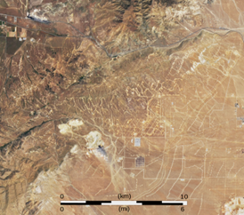

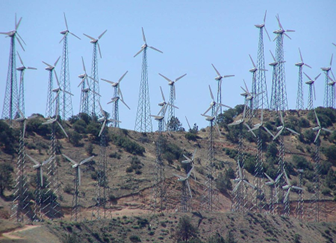

## Step 1. Create and prepare a new R project

You will use ArcGIS Pro for completing most of the analyses for this project. However, your report will be created and rendered in RStudio using Quarto. Begin by creating a new R project within an exercise #3 project directory (e.g., GEO336/exercise_03) in your general course folder. Here you will save files related to exercise #3. In File Explorer or RStudio, create the following folders within your R project’s working directory: “layers” (for storing GIS layers in both raster and vector formats), “maps” (for storing your ArcGIS map project), and “figures” (for storing exported maps and other images to be inserted into your report).

### Activate and extract R packages

Use the following code to activate the packages required to download and transform data needed for the exercise.

```r
library(dplyr) # data wrangling with pipe syntax
library(tidyverse) # data wrangling
library(sf) # simple features data package
library(sp) # spatial data package
library(terra) #
library(ggplot2) # creating plots
library(psych) # calculating summary statistics
library(raster) # create raster dataset
library(tmap)


options(scipen=999, digits = 2) # format output for data tables
```

### Download and extract GIS layers

Use the following code to download the [GIS layers](https://github.com/justenvirons/pedagogy/blob/main/data/layers.zip) from the GitHub repository into your project directory and extract the file’s contents into the “layers” folder. A list of the GIS layers that will be extracted into the layers folder are listed and briefly summarized below.

```r
temp <- tempfile()
download.file("https://github.com/justenvirons/pedagogy/raw/main/data/layers.zip",temp)
unzip(temp, exdir= "layers")
unlink(temp)
```

- Study area boundary (studyarea)
- Location of the origin substation in Kern County (line_source)
- Location of the destination substation in Los Angeles County (line_destination)
- Natural biodiversity ranked into five categories (biodiversity)
- Roads or categorized transportation routes (roads)
- Fire hazard risk ranked into four categories (firehazard)
- Elevation in meters (elevation)
- Population total (population) Earthquake fault lines (faultlines)

### Import and plot GIS layers in R

```r
# import raster layers
elevation <- raster("layers/elevation/w001001.adf")
biodiversity <- raster("layers/biodiversity/w001001.adf")
firehazard <- raster("layers/firehazard/w001001.adf")
population <- raster("layers/population/w001001.adf")

# import vector layers
studyarea <- st_read("layers/studyarea.shp")
line_source <- st_read("layers/line_source.shp")
line_destination <- st_read("layers/line_destination.shp")
roads <- st_read("layers/roads.shp")
faultlines <- st_read("layers/faultlines.shp")
```

## Step 2. Create and add data to ArcGIS Pro project

### Import GIS layers into ArcGIS Pro map project

Create a new ArcGIS Pro project on your computer under the maps directory in your R project folder. In your ArcGIS Pro map project via the “Catalog Pane” or, alternatively, click “Add Data” option under the “Map” menu on the toolbar and navigate to the *layer* folder in your project directory. Select all of the input layers and add to the current map frame. They should draw automatically and appear in the map’s table of contents.

## Step 3. Create new Quarto document to report alignment scenarios

In order to better understand the complexity of the proposed project, SCE wants you to create three unique scenarios for siting the transmission line using the datasets provided. For example, in one scenario you may attempt to maximize the long-term integrity of the transmission line while another scenario may maximize public safety or biodiversity.

Create a new [Quarto markdown document](https://quarto.org/) in your root R project working directory (e.g., “exercise03_report.qmd”) to report results of your alignment scenarios. (A rendered Word document version of the report is what you’ll submit to the exercise #3 D2L submission folder when completed.) You can use the following code as a template for your Quarto document. Refer to [Quarto web pages](https://quarto.org/docs/authoring/markdown-basics.html) for additional formatting guidelines.

```
---
title: "Exercise #3: Wind Energy Suitability Analysis"
author: "FirstName LastName"
date: "10/11/2023"
format:
  docx:
    output-file: "exercise_03_report.docx"
    mermaid:
      theme: neutral
editor_options:
chunk_output_type: console
---

# Alignment Scenario 1: Public Safety

## Dataset selection rationale:

Lorem ipsum dolor sit amet, consectetuer adipiscing elit. Mauris vitae risus interdum nibh facilisis adipiscing. Cras turpis felis, ultricies eu, vestibulum id, pellentesque at, quam. Nulla facilisi. Nulla aliquam, mauris tempus pulvinar eleifend, odio odio tincidunt pede, eget euismod tortor erat ac neque. In vel eros. Suspendisse auctor semper enim. Maecenas lorem eros, placerat eget, euismod vitae, adipiscing at, lorem. In vestibulum, lorem id tincidunt gravida, ipsum metus tempus mauris, ut vestibulum ipsum felis sit amet augue. Vivamus mattis vestibulum massa. Vivamus nisi metus, posuere at, iaculis non, vestibulum vitae, dolor. Nam blandit erat id lacus. Vivamus convallis lacinia nisi. Aliquam lacinia lacus vitae leo.

-   Lorem ipsum dolor sit amet, consectetuer adipiscing elit.
-   Nullam sed magna sed mi cursus tincidunt.
-   Nam mollis nunc in urna.
-   Nunc pretium rutrum nisi.

## Dataset prioritization rationale:

Aenean accumsan, velit eu dictum pellentesque, nunc sem fermentum leo, ut lobortis ante mi pellentesque quam. Quisque id neque. Donec sagittis nisi lobortis nibh. Cras venenatis quam nec dolor vulputate pulvinar. Proin luctus, diam sed pharetra fringilla, magna sem cursus lacus, ut mollis turpis augue id magna. Nullam bibendum, mauris ac venenatis volutpat, magna nunc aliquam pede, sollicitudin adipiscing tortor justo quis turpis. Aliquam blandit nulla et pede. Nulla facilisi.

@fig-line-plot shows the component layers and weighting scheme used to create the scenario-specific suitability map.

-   Donec interdum risus quis purus. (0.25)
-   Praesent ac orci sed purus suscipit blandit. (0.10)
-   Proin et augue et tortor pulvinar aliquam. (0.10)
-   Pellentesque euismod tincidunt mi. (0.55)

## Cumulative Cost Grid and Alignment Results:

![Scenario 1 Alignment Map](figures/s1_align.png)

Nunc venenatis ante nec dolor. Fusce sed sapien. Vivamus rutrum lacus in nisl. Donec sagittis, eros at fermentum posuere, libero metus dictum metus, ut aliquam tellus leo eu purus. Sed adipiscing sapien ac turpis. Vestibulum orci felis, mattis sit amet, interdum non, condimentum sit amet, mi. Praesent dignissim. Mauris ipsum enim, tincidunt at, semper id, sagittis sit amet, pede. Fusce dignissim. Phasellus quis tellus quis justo porta sagittis. Vivamus tincidunt lorem in metus. Morbi sit amet dolor. Nulla sollicitudin sem vel risus lacinia aliquam. Duis id sapien.

**Total distance:** XX miles **Total cost:** XX miles x \$1.5 million = \$XX million
```

Quarto also allows you to incorporate other visual elements into the document including diagrams. For example you use the below code to create a custom visual representation of the layers and procedures you used to create each scenario’s suitability layer. You can use the online [Mermaid live editor tool](https://mermaid.live) to customize the code before copying and pasting into the Quarto document. [Read more about diagramming in Quarto here](https://quarto.org/docs/authoring/diagrams.html).

```
flowchart TB
  L1[layer 1] --> W1{weight} --> E(scenario)
  L2[layer 2] --> W2{weight} --> E(scenario)
  L3[layer 3] --> W3{weight} --> E(scenario)
  L4[layer 4] --> W4{weight} --> E(scenario)
```

## Step 4: Select, derive and reclassify datasets

Identify three or more factors or GIS themes that you will use to model each scenario. For example, the long-term integrity of the transmission line may be enhanced by *minimizing* proximity to earth quake fault lines, fire hazard and steeper slopes (note that steep slopes make it difficult to repair and maintain transmission infrastructure).

In about 100 words, explain in the report (i.e., within the Quarto document) why you selected these three features themes or factors or how these factors speak to the particular alignment scenario. As part of your analysis you may need to *derive new datasets* from the original GIS themes. For example, you can use the “Euclidian Distance” tool (available under the Analysis/Toolbox in ArcGIS Pro) to create a distance to fault lines dataset. Keep track of new datasets by saving them to the working directory where the original data are located and by including a scenario-specific suffix (e.g., “s1” for scenario 1-related files) to each file name.

After selecting the three or more feature themes for each scenario, *reclassify* their values with respect to a standard scale or consistent range (e.g., make 1 the least cost/most desirable areas/values in the raster layer and 10 the highest cost/least desirable areas/values). For all utilized datasets, make sure that the maximum value represents the least desirable attributes whereas the minimum value represents a more desirable situation with respect to the transmission line alignment. For example, if you are trying to minimize fire risk, reclassify areas with the highest fire risk to 10 and areas with the lowest fire risk to 1.

The reclassify tool can be accessed via Analysis Tools menu or by typing “reclassify” into the Geoprocessing dialog box. Open the tool, select the input raster then click each entry and type the new value you wish the old value to become in the output raster (alternatively, use the “Classify” option to automate the categorization process). To remove an entry, select the entry, then click delete on the keyboard or add an entry by adding value in the bottom of the values table. When the boundary of two input ranges contain the same value, the higher end of the lower input range is inclusive, and the lower end of the higher input range is exclusive. Click Run to create the reclassified raster dataset.

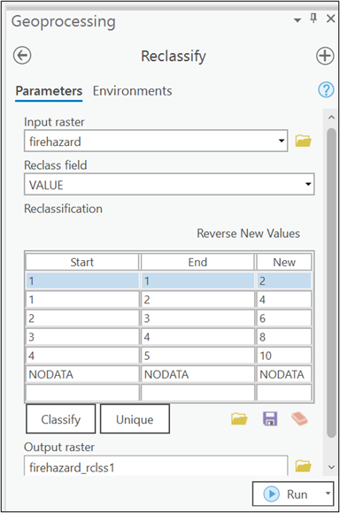

## Step 5. Prioritize and weight raster datasets

After selecting and reclassifying the scenario-specific feature themes, prioritize them with respect to their relative importance in the model. For example, you may prioritize or weight more heavily the importance of steep slopes relative to other feature themes included in the model given that dramatic relief will make it difficult to maintain the transmission line on a regular basis. Fire hazards and earth quakes, on the other hand, could be assigned lower weights or priorities given that they provide only sporadic threats to the line’s integrity. In 200 words, explain the logic underlying your prioritization scheme.

**Note**

For each set of scenario-specific feature themes, the sum of their relative weights should equal one. For example, the weight of the steeper slopes feature layer could be assigned a 0.5 whereas fire hazards and distance to fault lines 0.30 and 0.20, respectively.

Use the Raster Calculator tool to multiply the grid by the assigned weight. The Raster Calculator tool is under the Spatial Analyst toolbar. Build the expression in the box by typing directly into the box or adding raster layers, numbers and operators by clicking buttons in the dialog. Click Run to create the weighted raster dataset.

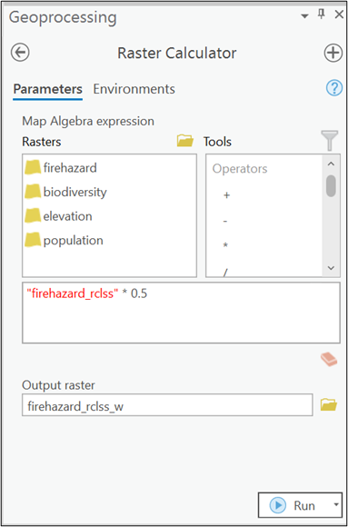

Weight raster datasets

## Step 6. Calculate cumulative cost grid and alignment

Once all of the input datasets for a particular scenario are prioritized or weighted, sum them using the raster calculator tool in ArcGIS Pro. As stated above, in order for the cumulative cost grid to be represented in the same scale as the input grids, the sum of the input weights must equal one. Adding all of the input grids will yield a scenario-specific cost grid representing the relative “suitability” of each pixel for the development of the transmission line.

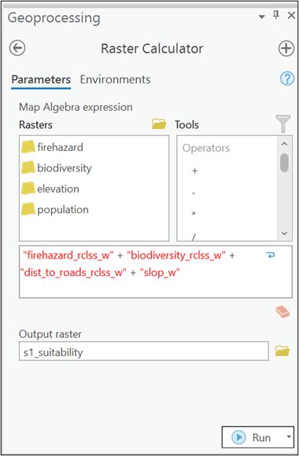

Sum weighted raster layers

## Step 7. Calculate the cost distance raster

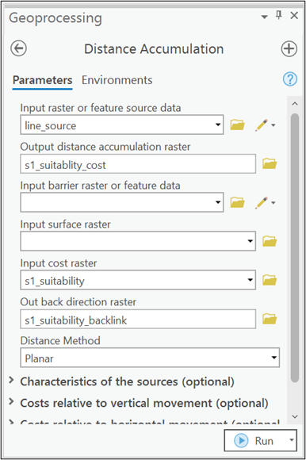

After you have calculated the cost distance and backlink grids, you are ready to estimate the *least cost alignment* or optimal cost path for the particular scenario using the “Optimal Path as Line” tool. The cost path function determines the path from a destination point (the Los Angeles county substation) to a source (the Kern county substation). The least-cost path travels from the destination to the source. This path is one cell wide, travels from the destination to the source, and is guaranteed to be the optimal transmission line alignment relative to the cost units defined by the cumulative cost raster created in previous steps. Specify the cumulative cost and backlink rasters in the Optimal Path as Line dialog and click Run to create the alignment as a feature layer. Overlay the proposed alignment path on the cumulative cost raster and copy map to your report.

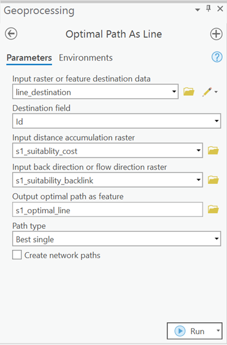

Calculate least cost alignment